# Efficient Trajectory Discovery with Adaptive Batch Sampling

Bayesian Optimization

Presenter: Arindam Fadikar

Argonne National Laboratory

May 17, 2026

## The Calibration Challenge

**Setup:** simulator $y = f(\theta) + \varepsilon$, observed data $y_\text{obs}$

**Optimization view**

Minimize a discrepancy $D(\theta) = d\!\left(\bar{f}(\theta),\, y_\text{obs}\right)$:

$$\theta^* = \arg\min_{\theta \in \Theta}\; D(\theta)$$

**Posterior inference view**

Treat $\theta$ as random; update beliefs via Bayes’ rule:

$$\pi(\theta \mid y_\text{obs}) \;\propto\; L(y_\text{obs} \mid \theta)\; \pi(\theta)$$

Both require **many** simulator evaluations at many $\theta$ values.

**Why is this hard in practice?**

- Models are **expensive** — each run takes minutes to hours on HPC
- Likelihoods are **intractable** — no closed-form expression
- Models are **stochastic** — same $\theta$, different output every run
- Need many runs per $\theta$ just to see through the noise
- Traditional calibration wastes most of the compute budget

## Why Trajectories? The Case Against Averaging

**Same parameters, different outputs — every single run**

In a stochastic simulator:

$$y = f(\theta), \quad r \sim \text{Uniform}$$

where $r$ is a **random seed** governing the stochastic path.

- Two runs with identical $\theta$ but different $r$ can look very different
- The **average** trajectory may never actually occur
- Averaging masks multimodality and loses the connection between parameters and specific epidemic paths

**Key shift:** instead of finding the best $\theta$, find many $(\theta, r)$ pairs that produce data-consistent **trajectories**.

[figure not shown]

A **trajectory** is a single model realization:

$$y(\theta, r) = f(\theta, r)$$

A **good trajectory** satisfies:
$$\text{RMSE}(y(\theta, r),\ y_\text{obs}) < \delta$$

**Why ensembles of trajectories?**

- Enables ensemble forecasting from calibrated runs
- Supports trajectory continuation when new surveillance data arrives
- More honest about model uncertainty

## What Existing Methods Lack

**Approximate Bayesian Computation**

- Simulate, compare to data via summary statistics
- Accept/reject based on distance threshold
- **Gap:** summary statistics discard trajectory-level information

**Emulation + Calibration**

- Build surrogate of $\mathbb{E}[f(\theta)]$ - non-replicate aware
- Optimize over $\theta$
- **Gap:** averaging over seeds before emulation loses the stochastic structure

All existing methods aggregate over randomness. The best-average parameters need not produce any data-consistent trajectory.

**The consequence:** with a fixed compute budget, mean-based surrogates return a handful of trajectories that *happen* to be close to data — they are not searching for trajectories explicitly.

## Trajectory-Oriented Optimization (TOO)

**Augment the input space:**

Instead of $f(\theta)$, model $f(\theta, r)$ — treating the random seed $r$ as an explicit input alongside parameters $\theta$.

- Now the simulator is a **deterministic function** of $(\theta, r)$
- We can build a surrogate over the joint $(\theta, r)$ space
- We search for good $(\theta, r)$ pairs, not just good $\theta$

This is the **Common Random Numbers (CRN)** idea, extended to the calibration setting (Chen, Ankenman, and Nelson 2012).

**Two ingredients needed:**

1. **Surrogate model** — emulates individual realizations $f(\theta, r)$; must respect seed structure
2. **Optimization algorithm** — searches the joint $(\theta, r)$ space efficiently under a limited simulation budget

Finding good $(\theta, r)$ pairs = **trajectory discovery**, not just parameter estimation.

## Common Random Numbers (CRN)

**Key insight: fixing the seed makes $f(\theta, r)$ smooth in $\theta$**

- Fix seed $r = r_0$, vary $\theta$ across its domain
- The output $f(\theta, r_0)$ varies smoothly with $\theta$
- A GP can interpolate this smooth function accurately
- Repeat for many seeds: each gives a “slice” of the output surface

CRN converts a noisy, non-smooth calibration surface into a collection of smooth functions — one per seed.

**Practical benefit:**

- Far fewer simulations needed to learn the surface
- Reuse the same seeds across parameter values
- Enables variance reduction via control variates
- Standard in simulation optimization literature

**Our choice of surrogate:** a **Gaussian Process (GP)** fitted over the joint $(\theta, r)$ space — exploiting CRN smoothness to interpolate individual trajectories efficiently.

## Gaussian Process: A Brief Primer

A **Gaussian Process** defines a distribution over functions:

$$z(x) \sim \mathrm{GP}\!\left(m(x),\; k(x, x')\right)$$

- $m(x)$: mean function (often $\equiv 0$)
- $k(x, x')$: **kernel** — encodes output similarity as a function of input distance
- **RBF kernel:** $k(x, x') = \exp\!\left(-\|x - x'\|^2 / 2\ell^2\right)$, where $\ell$ controls smoothness

**Posterior** at a new point $x_*$ is Gaussian:

$$z(x_*) \mid \mathrm{Data} \;\sim\; \mathrm{Normal}\!\left(\mu_*, \;\sigma^2_*\right)$$

with analytic $\mu_*$ and $\sigma^2_*$. Returns **uncertainty** alongside predictions.

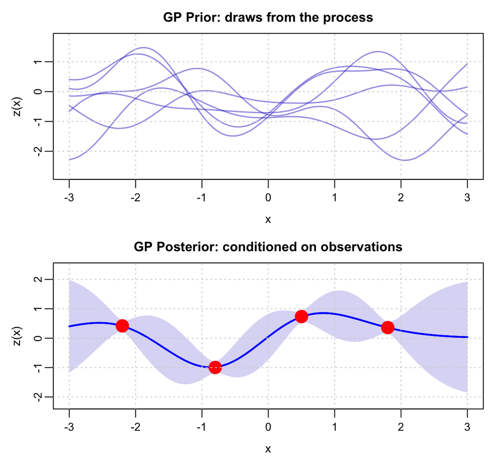

## The CRNGP Surrogate

**A Gaussian Process over the augmented $(\theta, r)$ space**

The surrogate models simulator output as:

$$f(\theta, r) \sim \mathrm{GP}\bigl(\mu(\theta, r),\ k((\theta,r),(\theta',r'))\bigr)$$

**Separable covariance kernel:**

$$k\bigl((\theta,r),(\theta',r')\bigr) = k_\theta(\theta, \theta') \times k_s(r, r')$$

where the seed kernel gives **constant inter-replicate correlation $\rho$** when $r \neq r'$:

$$k_s(r, r') = \begin{cases} 1 & r = r' \\ \rho & r \neq r' \end{cases}$$

**CRNGP** vs **HetGP**:

- HetGP (or any other non-replicate aware) learns a single mean surface $\mathbb{E}[f(\theta)]$ + variance
- CRNGP learns individual trajectory surfaces $f(\theta, r)$ per seed
- Result: CRNGP predicts which *specific* $(\theta, r)$ pair is good (Fadikar et al. 2023)

**What this gives us:**

- Borrows strength across seeds for the same $\theta$
- $\rho$ captures how much trajectories share structure
- Posterior predictions are fast exploiting kronecker structure in the design
- Uncertainty at both $\theta$ and $(\theta, r)$.

## CRNGP in Practice

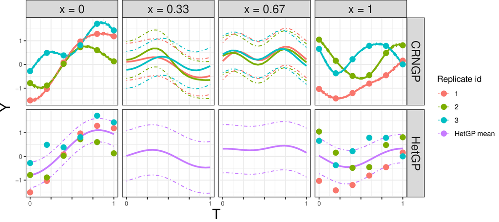

## CRNGP: Role of $\rho$

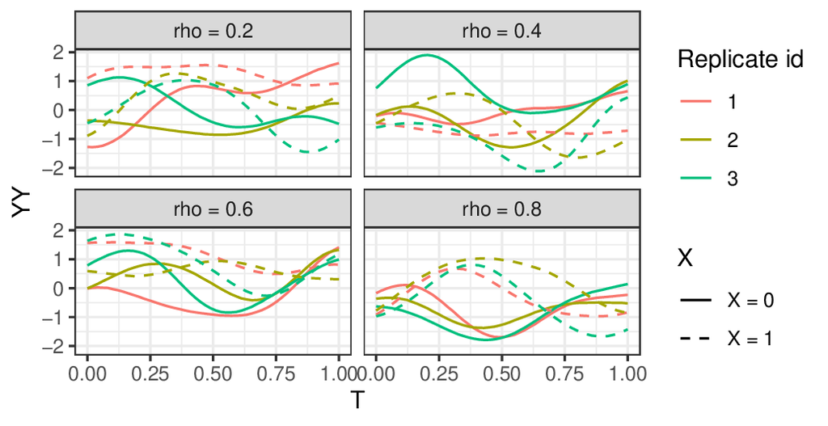

**The inter-replicate correlation $\rho$:**

- $\rho$ controls how much information is shared across seeds for the same $\theta$
- High $\rho$: trajectories from different seeds are treated as nearly exchangeable — more borrowing, smoother surface
- Low $\rho$: each seed is treated as an independent function — more flexibility, less borrowing
- $\rho$ is estimated from data via maximum likelihood, adapting to the actual seed-to-seed variability in the simulator

## Optimization: Thompson Sampling

**Using CRNGP to find good $(\theta, r)$ pairs**

**Algorithm:**

1. **Initialize** — run $n_\text{init}$ simulations on a Latin hypercube over $(\theta, r)$; fit CRNGP
2. **Repeat** until budget exhausted:
   - Draw a posterior sample $\tilde{f}$ from the CRNGP
   - Find $(\theta^*, r^*)$ minimizing $\|\tilde{f}(\theta, r) - y_\text{obs}\|^2$ over the candidate grid
   - Run simulator at $(\theta^*, r^*)$; update CRNGP

**Why Thompson Sampling?**

- Natuarally balance exploration vs exploitation
- Each draw can point to a different promising region
- Handles the multi-modal nature of the trajectory space gracefully
- Amenable to batch evaluation on HPC

**Key property:** the finite seed set $\mathrm{R} = \{r_1, \ldots, r_m\}$ makes the problem computationally tractable — we search over a discrete grid of $(\theta, r)$ pairs.

## Optimization: Thompson Sampling

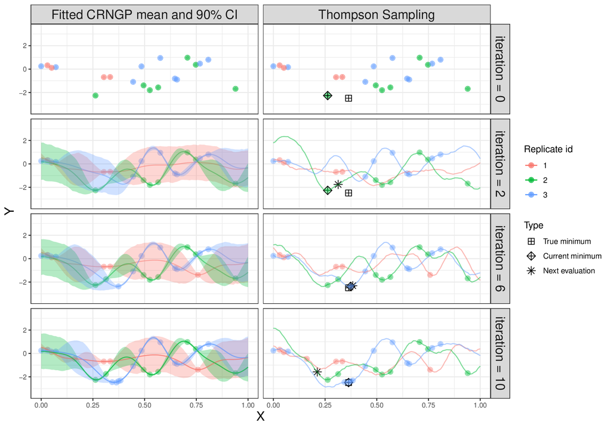

Thompson Sampling iteratively selects $(\theta, r)$ candidates by sampling from the CRNGP posterior and picking the point with lowest predicted discrepancy.

## Application: A COVID-19 model

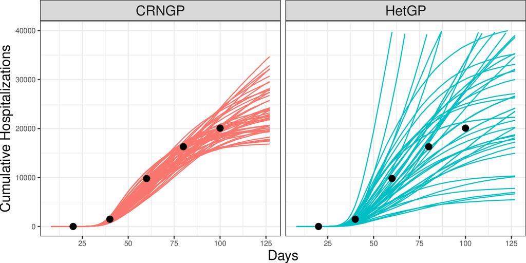

Best 50 trajectories of cumulative hospitalizations that are consistent with the observations denoted by black dots when using CRNGP and HetGP surrogates in Thompson sampling algorithm.

## Limitation : The Fixed Grid

**Thompson Sampling explores well — but only where the grid lives**

In this TOO setup, the candidate grid of $(\theta, r)$ pairs is **fixed at initialization**:

- If a promising region wasn’t covered by the initial design, it won’t be found
- With high-dimensional $\theta$, good regions are sparse and unlikely to be well-covered by a uniform initial design
- As the GP learns, the grid doesn’t adapt — budget spent sampling from regions already known to be poor

**Question:** can we make the grid *adapt* as the GP learns — focusing on promising regions dynamically?

## Adaptive Thompson Sampling (aCRN)

**Three steps per iteration**

**Step 1: Thompson Sampling**

- Maintain a grid of candidate $(\theta, r)$ pairs
- Draw a sample from the GP posterior
- Select batch of points with best predicted objective
- Evaluate simulator, update GP

**Step 2a: Adaptive Grid - Filter**

- Importance resample the grid using current objective estimates
- Concentrates candidates in high-likelihood regions
- Low-scoring $(\theta, r)$ pairs dropped

**Step 2b: Adaptive Grid - Densify**

- Run Metropolis–Hastings steps in $\theta$ space (seeds fixed)
- Proposes new $\theta$ near existing good points
- Accepted with probability:
  $$\alpha = \min\!\left\{1,\ \frac{L(\theta_\text{can}, r) \cdot q(\theta_\text{can} \mid \theta)}{L(\theta, r) \cdot q(\theta \mid \theta_\text{can})}\right\}$$

Filter + Densify together ensure the grid *tracks* promising regions as the GP learns.”

## Adaptive Grid TOO in Practice

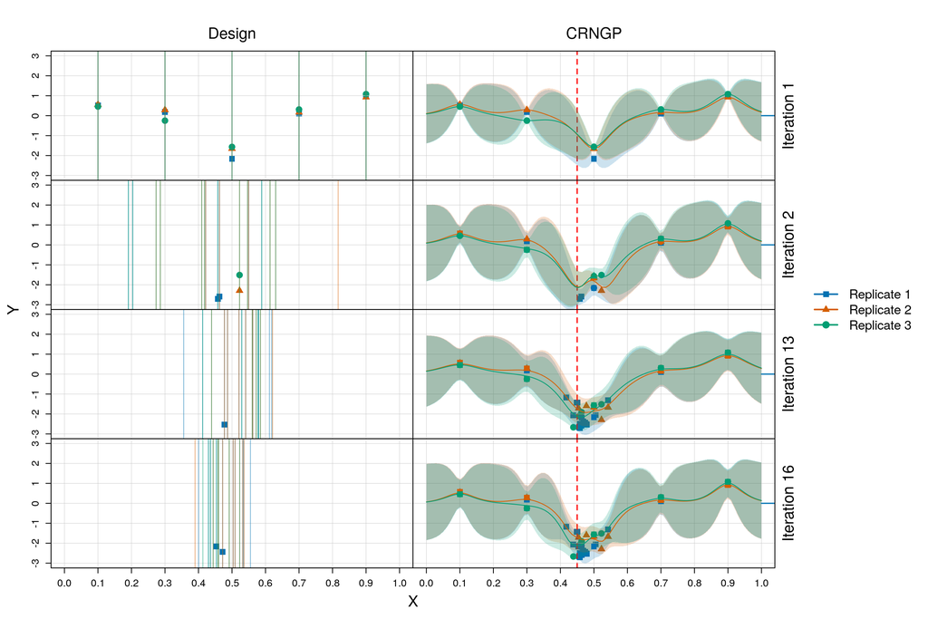

Illustration of adaptive grid TS with a CRNGP surrogate to find $(X, r)$ tuple having minimal $Y$ values.

## Simulated Experiment: Stochastic SIR Model

**A controlled testbed to compare methods**

**Model:** Discrete-time stochastic SIR with binomial transitions

- Infection rate $\beta \in [0, 1]$
- Recovery rate $\gamma \in [0, 1]$
- Trajectory: daily incidence curve

**Budget:** 300–700 simulations total

**Baselines:**

- **fCRN** — fixed grid, fixed seeds (no adaptation)
- **fgCRN** — fixed grid, flexible seeds
- **fHet** — heteroskedastic GP (standard approach)
- **aHet** — adaptive heteroskedastic GP

**Evaluation metrics:**

- Proportion of discovered trajectories with RMSE $< \delta$ (for $\delta \in \{15, 20, 25, 30\}$)
- **rAUC** — relative area under the proportion-vs-budget curve; higher = finds good trajectories faster
- Parameter space coverage

## Simulated Experiment: Stochastic SIR Model

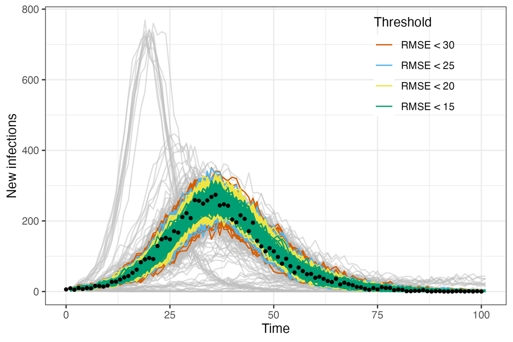

Simulated epidemic trajectories found by the aCRN method for a single experiment configuration.

## Simulated Experiment: Stochastic SIR Model

### Quality of Trajectories

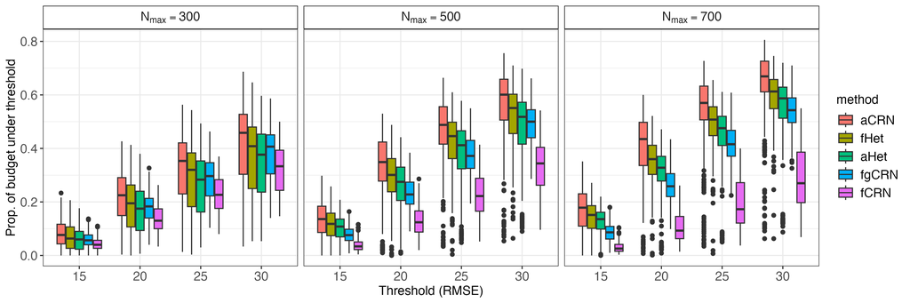

## Simulated Experiment: Stochastic SIR Model

### Time to Solution

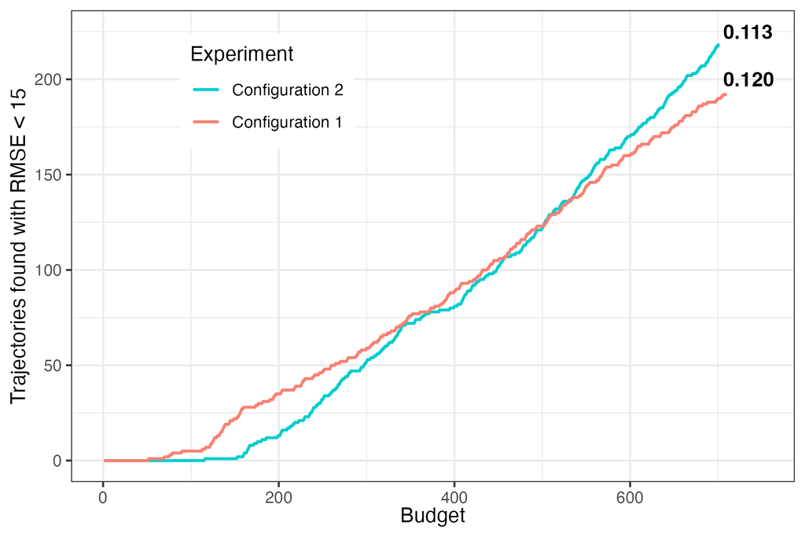

## Simulated Experiment: Stochastic SIR Model

### Time to Solution

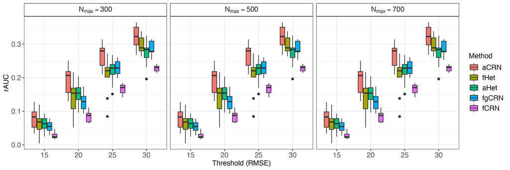

## Simulated Experiment: Stochastic SIR Model

### Parameter Exploration

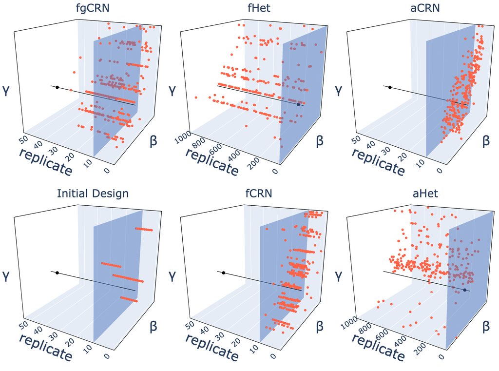

## Simulated Experiment: Stochastic SIR Model

### Parameter Exploration

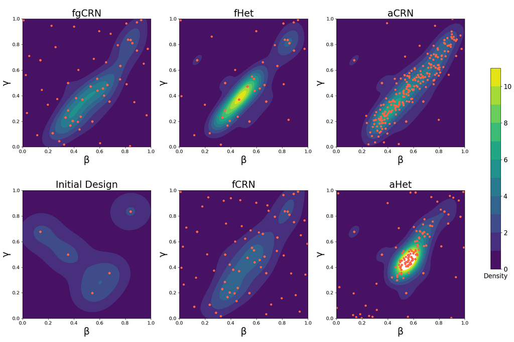

## Results: SIR Model

**aCRN outperforms all baselines across thresholds and budgets**

rAUC is highest for aCRN at every threshold level.

**Parameter space coverage:**

- fHet concentrates evaluations on a few grid points
- aCRN explores a broader region of $(\beta, \gamma)$ space
- Better coverage → more diverse calibrated trajectories

**Why does adaptation help?**

- Early iterations identify promising $\theta$ regions
- Grid refinement focuses compute there
- Thompson Sampling naturally balances exploration vs. exploitation
- Fixed-grid methods waste budget on uninformative regions

## Experiment: CityCOVID Agent-Based Model

**Scaling up to a real, expensive ABM**

**CityCOVID** simulates $\approx 2.7$ million agents in Chicago

- Agents have realistic activity schedules (home, work, school, community)
- COVID-19 transmission via contact networks
- Validated against Chicago public health data

**Three calibration parameters:**

- $\theta_1$: susceptibility probability $\in [0.01, 0.15]$
- $\theta_2$: stay-at-home compliance $\in [0.1, 1]$
- $\theta_3$: behavioral adjustment $\in [0.01, 0.5]$

**Target data:** Daily deaths + hospitalizations, Chicago, April–June 2020

**Computational setup:**

- Budget: **3,000 simulations** total
- Initial design: 20 parameter points × 30 replicates (600 runs)
- Each simulation: run on Argonne HPC via EMEWS framework

## Results: CityCOVID

**aCRN finds dramatically more calibrated trajectories**

| Threshold | aCRN | fHet |
| --- | --- | --- |
| $L < 15$ | **52 trajectories** | 1 trajectory |
| $L < 20$ | **149 trajectories** | 53 trajectories |

Within the same compute budget of 3,000 simulations.

**aCRN discovers 52× more high-quality trajectories at the tighter threshold.**

## A Summary

- Works in $(\theta, r)$ space — no information loss from averaging
- GP borrows strength across seeds via correlation $\rho$
- Adaptive grid tracks promising regions dynamically
- Thompson Sampling handles exploration-exploitation automatically
- Same simulator interface
- Parallelizable batch evaluation (HPC-friendly)

## Key Takeaways

1. **Seeds matter.** By treating them as inputs and we can get a richer calibration.
2. **Trajectory ensembles** Multiple plausible $(\theta, r)$ pairs give more accurate uncertainty quantification.
3. **Trajectory continuation is natural.** Once we have calibrated $(\theta, r)$ pairs, extending the simulation as new data arrives is straightforward.

#### Limitations and Future Work

- Fixed replicate set — seeds chosen at initialization, not adapted
- Constant inter-seed correlation $\rho$ — assumes uniform seed structure
- Scalar output summaries — doesn’t yet handle functional/multivariate outputs directly
- Grid size is a tuning parameter — requires some sensitivity analysis

## Conclusion

**Staying on Track: Efficient Trajectory Discovery with Adaptive Batch Sampling**

**Preprint:** arxiv.org/abs/2510.18099

[figure not shown]

Chen, Xi, Bruce E. Ankenman, and Barry L. Nelson. 2012. “The Effects of Common Random Numbers on Stochastic Kriging Metamodels.” *ACM Transactions on Modeling and Computer Simulation* 22 (2): 1–20.

Fadikar, Arindam, Nicholson Collier, Abby Stevens, Jonathan Ozik, Mickaël Binois, and Kok Ben Toh. 2023. “Trajectory-Oriented Optimization of Stochastic Epidemiological Models.” In *2023 Winter Simulation Conference (WSC)*, 1244–55. https://doi.org/10.1109/WSC60868.2023.10408258.